# india webscraping

Yadu

April 23, 2016

First, the following required packages are loaded and the working directory is set as follows.

```r
library(jsonlite)
library(httr)
library(tidyr)
library(dplyr)
```

```r
library(ggplot2)
library(maptools)
library(gpclib)
library(RColorBrewer)
setwd("/Users/chittampalliyashaswini/Desktop/Yadu")
```

Next, the provincial data for the GINI coefficient of India is scraped as follows and then spread out. Some of the spellings of the names of the provinces have to be changed so that they will match the names listed in the shape file.

```r
dat.india.province = subset(fromJSON("http://knoema.com/api/1.0/data/wiwuiff?Time=2005-2005&region=1000130,1000020,1000040,1000050,1000060,1000080,1000090,1000100,1000110,1000120,1000140,1000150,1000160,1000220,1000210,1000230,1000290,1000280,1000270,1000250&variable=1000130,1000140,1000070,1000080&Frequencies=A")$data, select = -c(Unit, Time, RegionId, Frequency, Scale))
dat.india.province = data.frame(spread(dat.india.province, variable, Value))
colnames(dat.india.province)[2:5] = c("PercentageRural", "PercentageUrban", "RuralGini", "UrbanGini")
dat.india.province$region[8] = "Jammu and Kashmir"
dat.india.province$region[14] = "Odisha"
```

Because this dataset does not include any information for Telangana, which was formed only recently, we can just subset the data so that we get data only for the province of Andhra Pradesh and just apply it to Telangana and then order the states in alphabetic order.

```r
dat.india.province = rbind(dat.india.province, data.frame(region = 'Telangana', subset(dat.india.province, region == "Andhra Pradesh", select = -c(region))))
dat.india.province = dat.india.province[order(dat.india.province$region),]
```

Now, for each province, we compute the GINI coefficient by weighting the rural GINI coefficient with the percentage of the rural population and the urban GINI coefficient with the percentage of the urban population.

```r
dat.india.province$GINI = ((dat.india.province$RuralGini)*(dat.india.province$PercentageRural) + (dat.india.province$UrbanGini)*(dat.india.province$PercentageUrban))/100
```

```r
dat.india = subset(fromJSON("http://knoema.com/api/1.0/data/wiwuiff?Time=2005-2005&variable=1000130,1000140,1000080,1000070&region=1000000&Frequencies=A")$data, select = -c(Unit, Time, RegionId, Frequency, Scale))
dat.india = data.frame(spread(dat.india, variable, Value))
colnames(dat.india)[2:5] = c("PercentageRural", "PercentageUrban", "RuralGini", "UrbanGini")
dat.india$GINI = ((dat.india$RuralGini)*(dat.india$PercentageRural) + (dat.india$UrbanGini)*(dat.india$PercentageUrban))/100
```

Now, we download the worldbank data and subset it so that it will include GINI coefficients only for 2005 and 2013. Because the GINI coefficient for 2005 for India is missing, the idea of the previous chunk was to scrape the urban and rural GINI coefficients for India and compute the weighted GINI coefficient and replace the NA for 2005 for India with that value.

```r
worlddata = subset(read.csv("/Users/chittampalliyashaswini/Desktop/Yadu/Data_Extract_From_World_Development_Indicators/worlddata.csv", sep = ","), select = c(Country.Name, X2005, X2013))
colnames(worlddata)[2] = "2005GINI"
colnames(worlddata)[3] = "2013GINI"
worlddata = worlddata[1:214,]
worlddata$`2005GINI` = as.numeric(as.vector(worlddata$`2005GINI`))
worlddata$`2013GINI` = as.numeric(as.vector(worlddata$`2013GINI`))
worlddata$`2005GINI` = as.vector(worlddata$`2005GINI`/100)
worlddata$`2013GINI` = as.vector(worlddata$`2013GINI`/100)
worlddata$`2005GINI`[worlddata$Country.Name == "India"] = dat.india$GINI
```

Now, we load the worldmap package and plot the map of the entire world and color each country according to its GINI coefficient.

```r
library(rworldmap)
n = joinCountryData2Map(worlddata, joinCode="NAME", nameJoinColumn="Country.Name")
```

```
## 207 codes from your data successfully matched countries in the map
## 7 codes from your data failed to match with a country code in the map
## 36 codes from the map weren't represented in your data
```

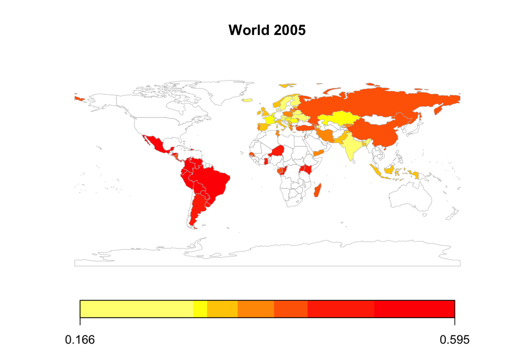

```r
mapCountryData(n, nameColumnToPlot="2005GINI", mapTitle="World 2005")
```

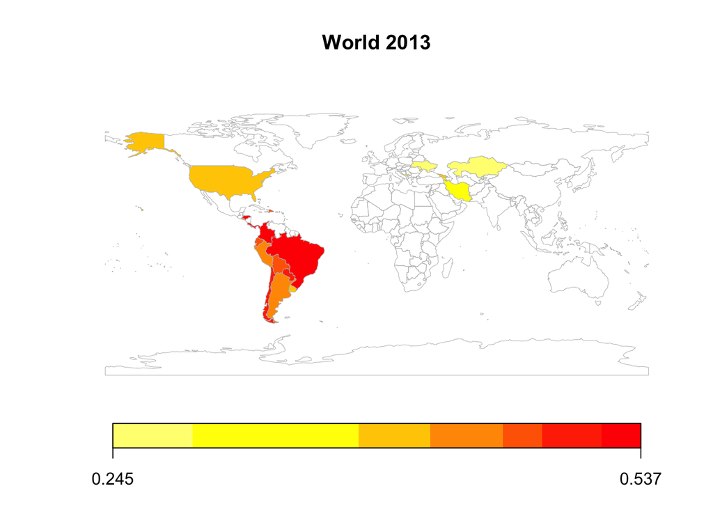

```r
mapCountryData(n, nameColumnToPlot="2013GINI", mapTitle="World 2013")
```

Now, we read in the shapefile for India and plot the map of India and color each province according to its GINI coefficient.

```r
library(classInt)
gpclibPermit()
```

```
## [1] TRUE
```

```r
gpclibPermitStatus()
```

```
## [1] TRUE
```

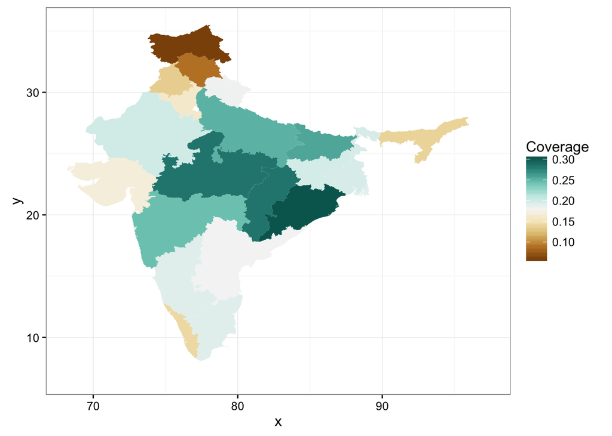

```r
map.ind.regions1 = readShapePoly("/Users/chittampalliyashaswini/Desktop/Yadu/IND_adm_shp/IND_adm1.shp", proj4string=CRS("+proj=longlat +datum=NAD27"))
map.ind.regions1 = fortify(map.ind.regions1, region = "NAME_1")
map.ind.regions1 = rename(map.ind.regions1,x=long,y=lat)
mycolors = brewer.pal(9,"BrBG")
ggplot(data=dat.india.province) + geom_map(aes(fill=GINI, map_id=region),map=map.ind.regions1) + expand_limits(map.ind.regions1) + theme_bw() + scale_fill_gradientn(name="Coverage", colours = mycolors)
```

http://databank.worldbank.org/data/reports.aspx?Code=SI.POV.GINI&id=af3ce82b&report_name=Popular_indicators&populartype=series&ispopular=y